# Melanoma cell lines: Data integration and LDA

Kostas Ntagiantas

June 25, 2018

The goal of this project is to integrate data from various experiment in an effort to get a better perspective of how melanoma cancerous cells proliferate, as well as build a profile of the disease with crucial genes and pathways that define it and distinguish several key cell lines from normal melanocyte cells. One issue that can be solved by the integration is the use of control melanocytes from across experiments. Therefore, the cell lines of the CCLE database, can now be included in a differential gene analysis with control melanocytes from other experiments.

## Datasets

All data used in this report were downloaded as CEL files from GEO database and converted to datasets with the rma method of **limma** package, with the exception of the CCLE data that was downloaded directly from the legacy portal of the CCLE website, that were already processed with the same rma algorithm. Each expressionset is saved as an *.rds* file and loaded in the workspace. The expression matrices are also saved and loaded to reduce compilation time.

| Experiment | Data |
| --- | --- |
| GSE7127 | 63 melanoma cell lines |
| GSE36133 | CCLE with many melanoma cell lines |
| GSE22301 | Melanoma cell lines & 4 melanocytes |
| GSE35388 | Melanoma cell line A375 & two melanocytes |

From those datasets, we extract only the expression matrix and the phenotype dataframe that will help with the batch effect detection. All of the cell lines in the CCLE datasets are cases of malignant melanoma. The cancerous cells, for the sake of this project, were all trated like cases of malignant melanoma.

## Data integration

First, the genes that are not present across all expression matrices are filtered out of the datasets. Then, the fold changes of the genes in the two datasets that involve melanoma cell lines and melanocyte controls are found with differential gene analysis. These fold changes will be next used to test if the integration of the data was successful.

## Principal Comoponents Analysis

Principal Components Analysis (PCA) must be conducted to see the general topology of the samples across all experiments. PCA will help validate the result of the integration.

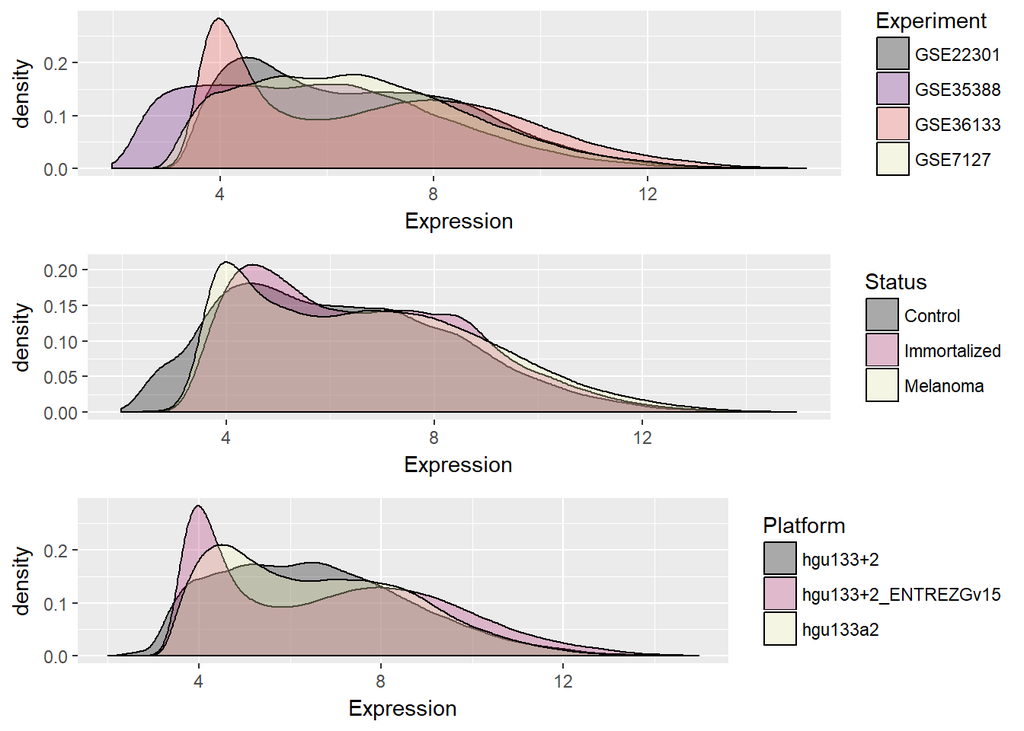

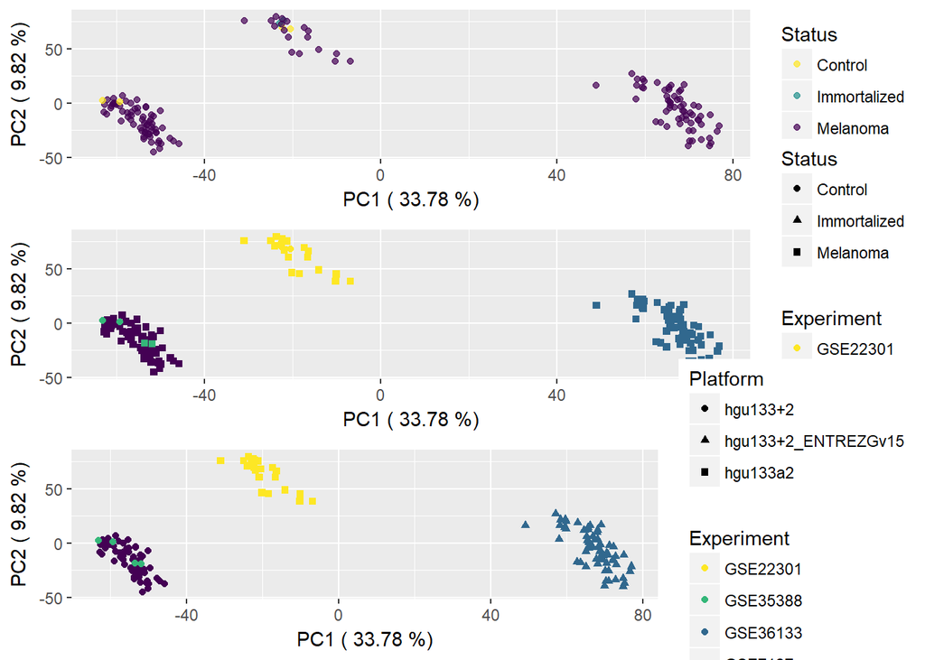

It is obvious that the four experiments are heavily dependent on the platform across whicheach experiment was done. Thus the batch for the batch effect removal and the integration of the experiments will be the platform. Batch effect removal is conducted through the use of *ComBat* function in the **sva** package.

[figure not shown]

The data integration through ComBat seems to have nice results. A more thorough cehck is performed by checking the changes of the logFC in the experiments, before and after the integration.

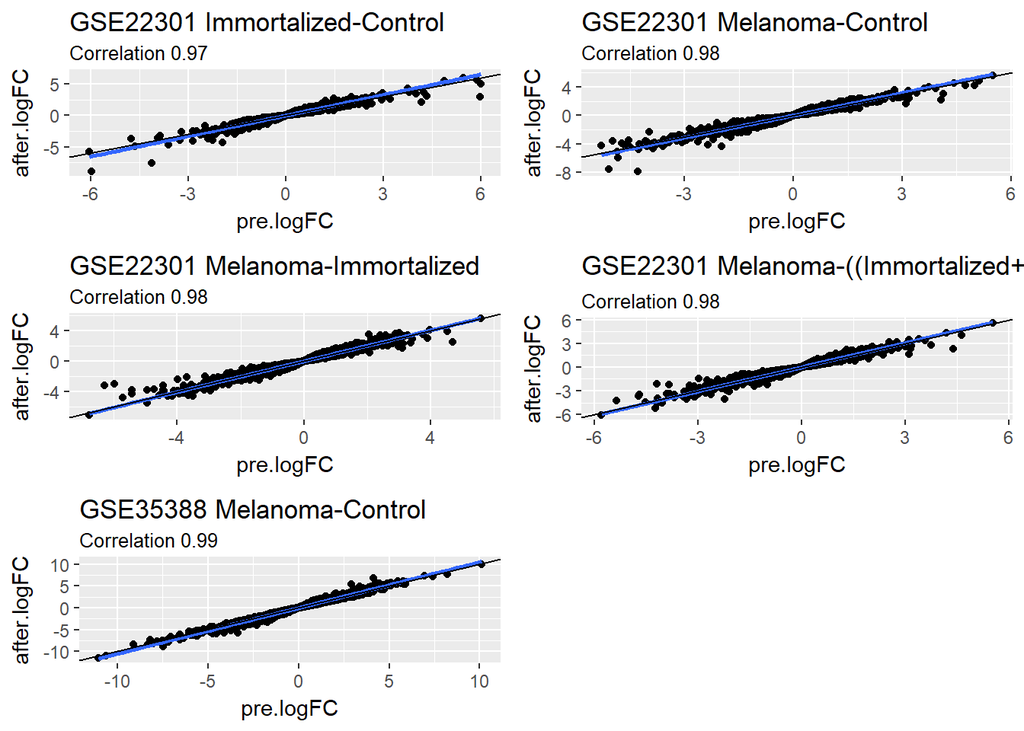

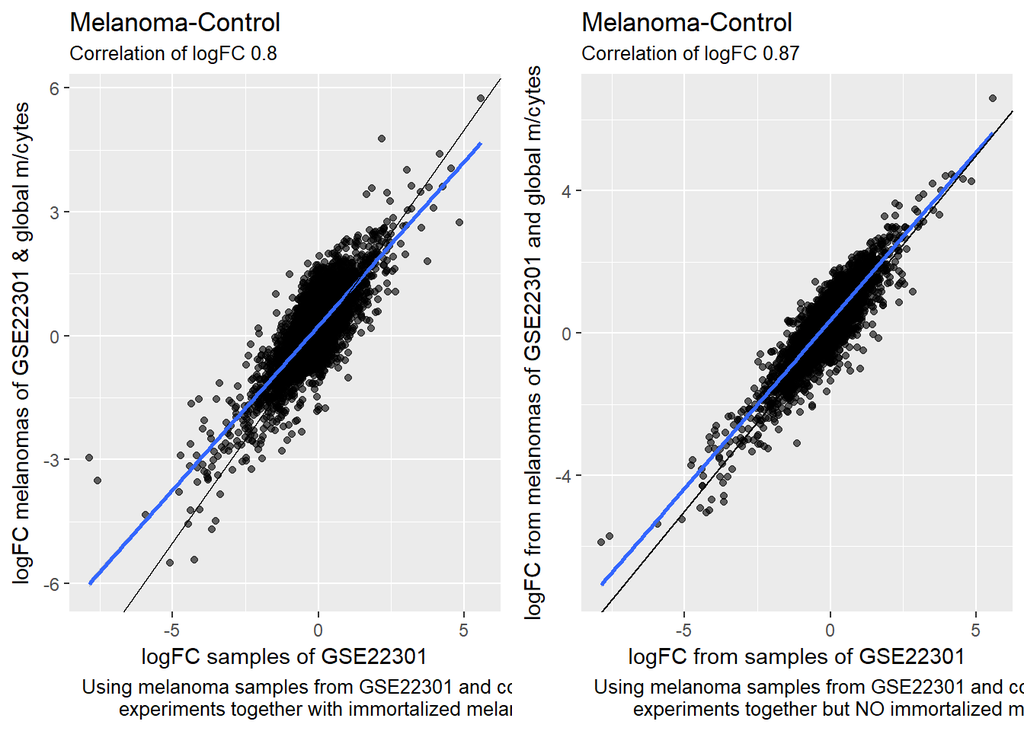

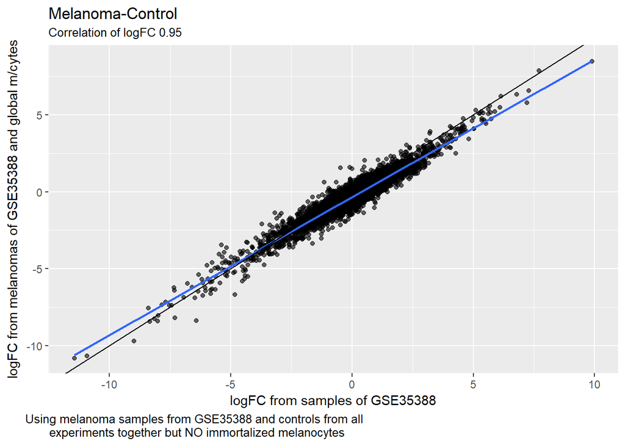

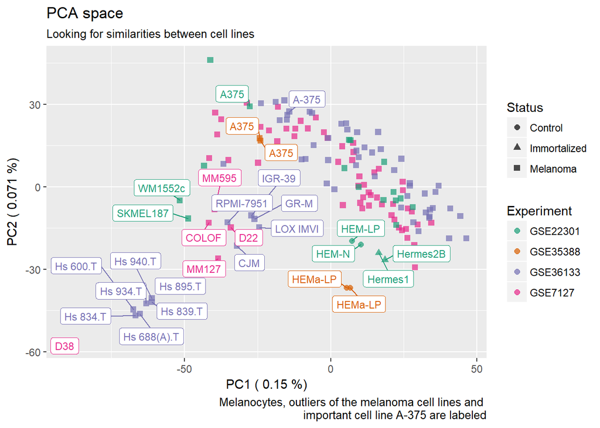

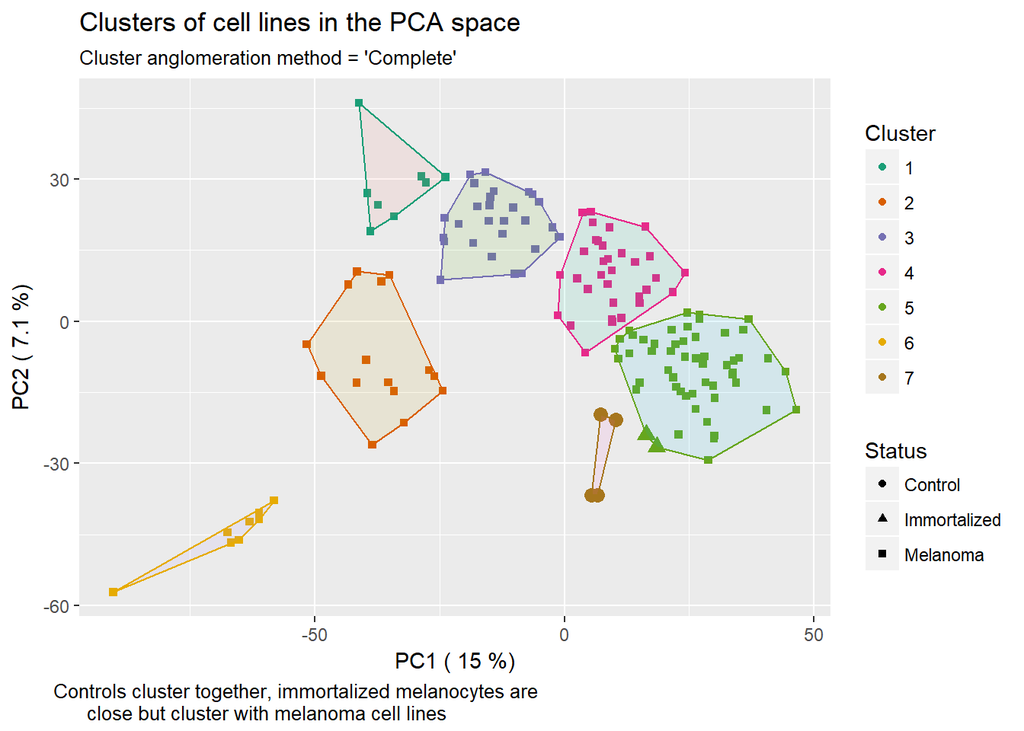

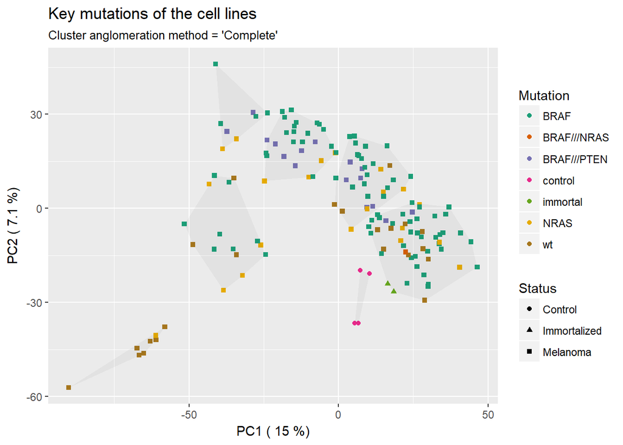